# matplotlib.colors.ListedColormap

**class*matplotlib.colors.ListedColormap(*colors*, *name='from_list'*, *N=None*)[[source]](https://github.com/matplotlib/matplotlib/blob/v3.10.8/lib/matplotlib/colors.py#L1166-L1258)**

Bases: `Colormap`

Colormap object generated from a list of colors.

This may be most useful when indexing directly into a colormap, but it can also be used to generate special colormaps for ordinary mapping.

**Parameters:**

**colors**list, array**

Sequence of Matplotlib color specifications (color names or RGB(A) values).

**name**str, optional**

String to identify the colormap.

**N**int, optional**

Number of entries in the map. The default is *None*, in which case there is one colormap entry for each element in the list of colors. If

```
N < len(colors)
```

the list will be truncated at *N*. If

```
N > len(colors)
```

the list will be extended by repetition.

**Parameters:**

**name**str**

The name of the colormap.

**N**int**

The number of RGB quantization levels.

**resampled(*lutsize*)[[source]](https://github.com/matplotlib/matplotlib/blob/v3.10.8/lib/matplotlib/colors.py#L1224-L1232)**

Return a new colormap with *lutsize* entries.

**reversed(*name=None*)[[source]](https://github.com/matplotlib/matplotlib/blob/v3.10.8/lib/matplotlib/colors.py#L1234-L1258)**

Return a reversed instance of the Colormap.

**Parameters:**

**name**str, optional**

The name for the reversed colormap. If None, the name is set to `self.name + "_r"`.

**Returns:**

**ListedColormap**

A reversed instance of the colormap.

## Examples using `matplotlib.colors.ListedColormap`

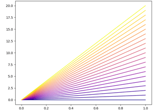

[Selecting individual colors from a colormap](https://matplotlib.org/stable/gallery/color/individual_colors_from_cmap.html)

Selecting individual colors from a colormap

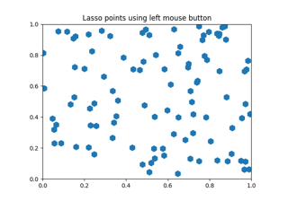

[Lasso Demo](https://matplotlib.org/stable/gallery/event_handling/lasso_demo.html)

Lasso Demo

[Layer images with alpha blending](https://matplotlib.org/stable/gallery/images_contours_and_fields/layer_images.html)

Layer images with alpha blending

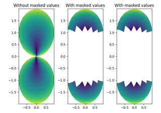

[QuadMesh Demo](https://matplotlib.org/stable/gallery/images_contours_and_fields/quadmesh_demo.html)

QuadMesh Demo

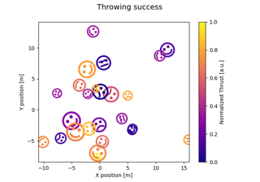

[Mapping marker properties to multivariate data](https://matplotlib.org/stable/gallery/lines_bars_and_markers/multivariate_marker_plot.html)

Mapping marker properties to multivariate data

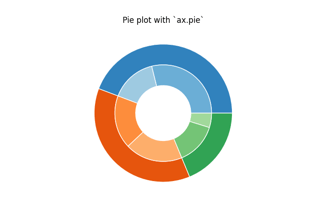

[Nested pie charts](https://matplotlib.org/stable/gallery/pie_and_polar_charts/nested_pie.html)

Nested pie charts

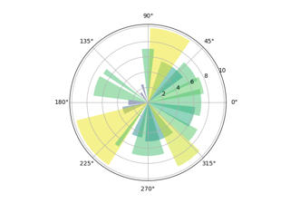

[Bar chart on polar axis](https://matplotlib.org/stable/gallery/pie_and_polar_charts/polar_bar.html)

Bar chart on polar axis

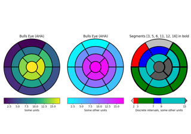

[Left ventricle bullseye](https://matplotlib.org/stable/gallery/specialty_plots/leftventricle_bullseye.html)

Left ventricle bullseye

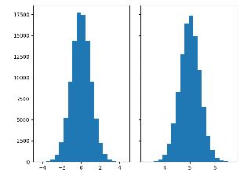

[Histograms](https://matplotlib.org/stable/gallery/statistics/hist.html)

Histograms

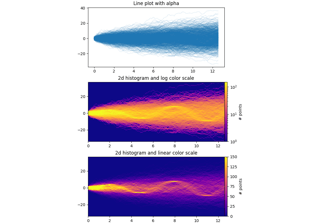

[Time Series Histogram](https://matplotlib.org/stable/gallery/statistics/time_series_histogram.html)

Time Series Histogram

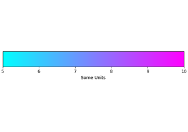

[Customized Colorbars Tutorial](https://matplotlib.org/stable/users/explain/colors/colorbar_only.html)

Customized Colorbars Tutorial

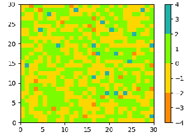

[Creating Colormaps in Matplotlib](https://matplotlib.org/stable/users/explain/colors/colormap-manipulation.html)

Creating Colormaps in Matplotlib

© 2012–2026 Matplotlib Development Team. All rights reserved.  
Licensed under the Matplotlib License Agreement.  
https://matplotlib.org/stable/api/_as_gen/matplotlib.colors.ListedColormap.html